# Lab 6 - Multivariate

Julia Burmistrova

Using the Bay Delta WQ dataset:

1. For the Water Years 2005-2012, develop a predictive model of the mean monthly Chl-a concentration in the California Bay Delta using other mean monthly water quality variables.

Be sure to show your work, including multiple model comparison (or step models), provide quantification and explain the reasoning behind your final model selection. * Below you will find (1) Data Wrangling, (2) Check for correlation and regression assumptions, (3) A summary and comparison of 4 models developed

Which variables are highly correlated with the others? How did you account for this? * Below, in the (2) check for regression assumptions, you will see a check of highly correlated variables Be sure to demonstrate that you have accounted for all assumptions in your regression. * Assumptions are Identify any badly fitted observations, discuss whether your residuals are following expected patterns, and discuss whether there are any possible explanations for any poorly modeled observations. * Badly fitted observations: `Nitrite + Nitrate (Dissolved)` + `Organic Nitrogen (Dissolved)` + `Ammonia (Dissolved)` `Phosphorus (Total)` + `Ortho-phosphate (Dissolved)` - Possible explanations for poor fit: observations are correlated and covered in another observation (like total instead of just dissolved), there is no relationship to Chl-a, data was not properly collected and there actually is a good relationship with Chl-a * Well fitted observations: `Kjeldahl Nitrogen (Total)` + Oxygen + Temperature - Oxygen and Temperature are highly correlated so I think that this is overfitting * Residuals are found in (3) A summary and comparison of 4 models developed Quantify how much variance in mean monthly Chl-a is explained by the variables you selected. * Variance is shown in (3) A summary and comparison of 4 models developed, the AIC for each variable is calculated in the step(lm()) nested function. * Temperature showed the most explanation for Chl-a prediction * Best model was the EPA model that included Temp, Oxygen, and Kjeldal Nit. - Had the highest adj-R^2 and the lowest AIC

```r
require(tidyverse)
require(lubridate)
require(corrplot)
require(ggpubr)
require(broom)
```

### (1) Data Wrangling

```r
wq.dat <- read_csv("BayDeltaWQ.csv")
```

[output not shown]

```r
#water year function found: https://stackoverflow.com/questions/40351788/plotting-a-non-standard-year-water-year-with-ggplot2
wtr_yr <- function(dates, start_month=10) {
  # Convert dates into POSIXlt
  dates.posix = as.POSIXlt(dates)
  # Year offset
  offset = ifelse(dates.posix$mon >= start_month - 1, 1, 0)
  # Water year
  adj.year = dates.posix$year + 1900 + offset
  # Return the water year
  adj.year
}
wq.dat <- add_column(wq.dat, WaterYear = wtr_yr(wq.dat$SampleDate))
wq.dat <-  add_column(wq.dat, Month = month(wq.dat$SampleDate))
wq.dat.05_12 <- subset(wq.dat, WaterYear > 2004 & WaterYear < 2013)
wq.dat.05_12[4:104] <- lapply(wq.dat.05_12[4:104], as.numeric)
```

```
NAs introduced by coercion
```

```r
head(wq.dat.05_12)
```

| X1 | SampleDate | StationCode | Depth | 1% Light Depth | Conductance (EC) | SiteDepth | Field Notes | Fluorescence | Latitude | Longitude | Oxygen | pH | Secchi Depth | Temperature | Tide Stage | Tide Time | Turbidity | Weather Observations | Wind Direction | Wind Velocity | VarType | Alachlor | Aldrin | Ammonia (Dissolved) | Ammonia (Total) | Arsenic (Dissolved) | Arsenic (Total) | Atra+Simazine (Atrazine & Simazine) | Atrazine | … |
| --- | --- | --- | --- | --- | --- | --- | --- | --- | --- | --- | --- | --- | --- | --- | --- | --- | --- | --- | --- | --- | --- | --- | --- | --- | --- | --- | --- | --- | --- | --- |
| 12573 | 2004-10-18 | D16 | 3 | NA | 884 | 39.0 | NA | 1.2 | NA | NA | 8.8 | NA | 76 | 18.5 | NA | NA | NA | NA | NA | NA | NA | NA | NA | NA | NA | NA | NA | NA | NA | … |
| 12574 | 2004-10-18 | D19 | 3 | NA | 928 | 20.3 | NA | 1.2 | NA | NA | 8.7 | NA | 120 | 18.6 | NA | NA | NA | NA | NA | NA | NA | NA | NA | NA | NA | NA | NA | NA | NA | … |
| 12575 | 2004-10-18 | D26 | 3 | NA | 293 | 41.0 | NA | 1.2 | NA | NA | 8.5 | NA | 92 | 18.6 | NA | NA | NA | NA | NA | NA | NA | NA | NA | NA | NA | NA | NA | NA | NA | … |
| 12576 | 2004-10-18 | D28A | 3 | NA | 626 | 17.7 | NA | 1.2 | NA | NA | 8.5 | NA | 182 | 18.8 | NA | NA | NA | NA | NA | NA | NA | NA | NA | NA | NA | NA | NA | NA | NA | … |
| 12577 | 2004-10-19 | MD10A | 3 | NA | 263 | 18.0 | NA | 3.8 | NA | NA | 8.0 | NA | 110 | 18.2 | NA | NA | NA | NA | NA | NA | NA | NA | NA | NA | NA | NA | NA | NA | NA | … |
| 12578 | 2004-10-19 | P8 | 3 | NA | 779 | 38.5 | NA | 2.8 | NA | NA | 6.8 | NA | 76 | 19.1 | NA | NA | NA | NA | NA | NA | NA | NA | NA | NA | NA | NA | NA | NA | NA | … |

```r
wq.dat.05_12.no.na <- wq.dat.05_12 #seeding dataframe
n <- 1
ccount <- 0
for (i in 1:104) { #I'm so sorry for my horrendous for loop
  if (all(is.na(wq.dat.05_12[,i])) == T) {
    ccount[n] <- i
    n = n+1
  }
}
ccount <- as.double(ccount)
wq.dat.05_12.no.na <- wq.dat.05_12.no.na[-ccount]
head(wq.dat.05_12.no.na)
```

| X1 | SampleDate | StationCode | Depth | Conductance (EC) | SiteDepth | Field Notes | Fluorescence | Latitude | Longitude | Oxygen | pH | Secchi Depth | Temperature | Turbidity | Ammonia (Dissolved) | Calcium (Dissolved) | Chloride (Dissolved) | Chlorophyll a | Kjeldahl Nitrogen (Total) | Nitrite + Nitrate (Dissolved) | Organic Carbon (Dissolved) | Organic Carbon (Total) | Organic Nitrogen (Dissolved) | Ortho-phosphate (Dissolved) | Pheophytin a | Phosphorus (Total) | Silica (SiO2) (Dissolved) | Solids (Total Dissolved) | Solids (Total Suspended) | … |
| --- | --- | --- | --- | --- | --- | --- | --- | --- | --- | --- | --- | --- | --- | --- | --- | --- | --- | --- | --- | --- | --- | --- | --- | --- | --- | --- | --- | --- | --- | --- |
| 12573 | 2004-10-18 | D16 | 3 | 884 | 39.0 | NA | 1.2 | NA | NA | 8.8 | NA | 76 | 18.5 | NA | NA | NA | NA | NA | NA | NA | NA | NA | NA | NA | NA | NA | NA | NA | NA | … |
| 12574 | 2004-10-18 | D19 | 3 | 928 | 20.3 | NA | 1.2 | NA | NA | 8.7 | NA | 120 | 18.6 | NA | NA | NA | NA | NA | NA | NA | NA | NA | NA | NA | NA | NA | NA | NA | NA | … |
| 12575 | 2004-10-18 | D26 | 3 | 293 | 41.0 | NA | 1.2 | NA | NA | 8.5 | NA | 92 | 18.6 | NA | NA | NA | NA | NA | NA | NA | NA | NA | NA | NA | NA | NA | NA | NA | NA | … |
| 12576 | 2004-10-18 | D28A | 3 | 626 | 17.7 | NA | 1.2 | NA | NA | 8.5 | NA | 182 | 18.8 | NA | NA | NA | NA | NA | NA | NA | NA | NA | NA | NA | NA | NA | NA | NA | NA | … |
| 12577 | 2004-10-19 | MD10A | 3 | 263 | 18.0 | NA | 3.8 | NA | NA | 8.0 | NA | 110 | 18.2 | NA | NA | NA | NA | NA | NA | NA | NA | NA | NA | NA | NA | NA | NA | NA | NA | … |
| 12578 | 2004-10-19 | P8 | 3 | 779 | 38.5 | NA | 2.8 | NA | NA | 6.8 | NA | 76 | 19.1 | NA | NA | NA | NA | NA | NA | NA | NA | NA | NA | NA | NA | NA | NA | NA | NA | … |

```r
wq.dat.05_12.mean <- wq.dat.05_12.no.na %>%
  group_by(Month, WaterYear) %>%
  summarize_all(mean, na.rm = TRUE)
```

[output not shown]

```r
head(wq.dat.05_12.mean)
```

| Month | WaterYear | X1 | SampleDate | StationCode | Depth | Conductance (EC) | SiteDepth | Field Notes | Fluorescence | Latitude | Longitude | Oxygen | pH | Secchi Depth | Temperature | Turbidity | Ammonia (Dissolved) | Calcium (Dissolved) | Chloride (Dissolved) | Chlorophyll a | Kjeldahl Nitrogen (Total) | Nitrite + Nitrate (Dissolved) | Organic Carbon (Dissolved) | Organic Carbon (Total) | Organic Nitrogen (Dissolved) | Ortho-phosphate (Dissolved) | Pheophytin a | Phosphorus (Total) | Silica (SiO2) (Dissolved) | … |
| --- | --- | --- | --- | --- | --- | --- | --- | --- | --- | --- | --- | --- | --- | --- | --- | --- | --- | --- | --- | --- | --- | --- | --- | --- | --- | --- | --- | --- | --- | --- |
| 1 | 2005 | 21226.29 | 2005-01-18 | NA | 3 | 7018.000 | 36.53182 | NaN | 1.766364 | 38.05143 | -121.8943 | 9.432800 | NaN | 44.65217 | 8.961600 | 103.3333 | 0.15642857 | NaN | 2093.9286 | 0.9232143 | 0.8357143 | 0.6800000 | NaN | NaN | 0.5571429 | 0.11428571 | 1.1332143 | 0.22357143 | 15.70000 | … |
| 1 | 2006 | 21584.72 | 2006-01-23 | NA | 3 | 3712.455 | 34.84348 | NaN | 1.690909 | 38.05917 | -121.9855 | 9.572500 | NaN | 44.13043 | 10.429167 | 14.0000 | 0.06769231 | NaN | 875.6923 | 1.6750000 | 0.4181818 | 0.5123077 | NaN | NaN | 0.2900000 | 0.06153846 | 0.6223333 | 0.10615385 | 15.75385 | … |
| 1 | 2007 | 20914.52 | 2007-01-15 | NA | 3 | 10620.379 | 31.27391 | NaN | 2.155357 | 38.07200 | -121.7764 | 10.666667 | 7.650 | 53.34783 | 8.076667 | 12.0000 | 0.15615385 | NaN | 3755.3077 | 3.0137037 | 0.5153846 | 0.7461538 | NaN | NaN | 0.4230769 | 0.05230769 | 1.7207407 | 0.08923077 | 13.86923 | … |
| 1 | 2008 | 21333.00 | 2008-01-16 | NA | 3 | 8906.565 | 35.22174 | NaN | 2.163636 | 38.05042 | -121.9084 | 9.495833 | NaN | 43.86957 | 9.066667 | NaN | 0.19692308 | NaN | 2768.6923 | 1.6866667 | 0.9769231 | 1.0538462 | NaN | NaN | 0.8000000 | 0.08846154 | 1.7280952 | 0.18230769 | 16.86154 | … |
| 1 | 2009 | 21616.00 | 2009-01-16 | NA | 3 | 12234.619 | 28.41429 | NaN | 1.350000 | 38.08759 | -121.7492 | 9.765909 | NaN | 81.52381 | 9.327273 | 8.0000 | 0.20545455 | NaN | 4202.1538 | 2.1850000 | 0.7153846 | 0.9061538 | NaN | NaN | 0.3923077 | 0.07769231 | 0.6654545 | 0.10615385 | 14.99231 | … |
| 1 | 2010 | 21893.50 | 2010-01-08 | NA | 3 | 16252.000 | 31.84783 | NaN | 1.863636 | 38.08050 | -121.7597 | 9.620833 | 7.543 | 79.91304 | 9.695833 | 13.0000 | 0.15933333 | NaN | 3778.7333 | 1.6714286 | 0.5400000 | 0.7713333 | NaN | NaN | 0.2600000 | 0.06066667 | 1.3990476 | 0.10666667 | 14.37333 | … |

```r
season <- 1 #seeding season
for (i in 1:length(wq.dat.05_12.mean$Month)) {
   if (wq.dat.05_12.mean$Month[i] == 1) {
    season[i] <- "wet" }
   else if (wq.dat.05_12.mean$Month[i] == 2) {
    season[i] <- "wet" }
   else if (wq.dat.05_12.mean$Month[i] == 3) {
    season[i] <- "wet" }
   else if (wq.dat.05_12.mean$Month[i] == 4) {
    season[i] <- "wet" }
   else if (wq.dat.05_12.mean$Month[i] == 5) {
    season[i] <- "dry" }
   else if (wq.dat.05_12.mean$Month[i] == 6) {
    season[i] <- "dry" }
   else if (wq.dat.05_12.mean$Month[i] == 7) {
    season[i] <- "dry" }
   else if (wq.dat.05_12.mean$Month[i] == 8) {
    season[i] <- "dry" }
   else if (wq.dat.05_12.mean$Month[i] == 9) {
    season[i] <- "dry" }
   else if (wq.dat.05_12.mean$Month[i] == 10) {
    season[i] <- "dry" }
   else if (wq.dat.05_12.mean$Month[i] == 11) {
    season[i] <- "wet" }
   else if (wq.dat.05_12.mean$Month[i] == 12) {
    season[i] <- "wet" }
}
year <- wq.dat.05_12.mean$year
```

```
Unknown or uninitialised column: 'year'.
```

```r
wq.dat.05_12.mean <- wq.dat.05_12.mean[-4]
wq.dat.05_12.mean[is.na(wq.dat.05_12.mean)] <- NA
```

So I removed Depth because all of the values were 3, so that factor is not helpful. I removed Latitude and Longitude because those values don’t seem to be helpful either.

We’re looking at Chlorophyll, so that has to do with Nutrients, maybe Temperature, Oxygen (eutrophication) (source:https://www.epa.gov/national-aquatic-resource-surveys/indicators-chlorophyll)

```r
wq.dat.05_12.mean <- wq.dat.05_12.mean[-c(1,2,3,4)] #take out Month, WaterYear, X1 and Station Code
wq.dat.05_12.mean <- wq.dat.05_12.mean[-c(4)] #take out Field Notes
wq.dat.05_12.mean <- wq.dat.05_12.mean[-c(1, 5, 6)] #take out Depth, Lat, Long
head(wq.dat.05_12.mean)
```

| Conductance (EC) | SiteDepth | Fluorescence | Oxygen | pH | Secchi Depth | Temperature | Turbidity | Ammonia (Dissolved) | Calcium (Dissolved) | Chloride (Dissolved) | Chlorophyll a | Kjeldahl Nitrogen (Total) | Nitrite + Nitrate (Dissolved) | Organic Carbon (Dissolved) | Organic Carbon (Total) | Organic Nitrogen (Dissolved) | Ortho-phosphate (Dissolved) | Pheophytin a | Phosphorus (Total) | Silica (SiO2) (Dissolved) | Solids (Total Dissolved) | Solids (Total Suspended) | Solids (Volatile Suspended) |
| --- | --- | --- | --- | --- | --- | --- | --- | --- | --- | --- | --- | --- | --- | --- | --- | --- | --- | --- | --- | --- | --- | --- | --- |
| 7018.000 | 36.53182 | 1.766364 | 9.432800 | NA | 44.65217 | 8.961600 | 103.3333 | 0.15642857 | NA | 2093.9286 | 0.9232143 | 0.8357143 | 0.6800000 | NA | NA | 0.5571429 | 0.11428571 | 1.1332143 | 0.22357143 | 15.70000 | 3730.214 | 41.28571 | 6.461538 |
| 3712.455 | 34.84348 | 1.690909 | 9.572500 | NA | 44.13043 | 10.429167 | 14.0000 | 0.06769231 | NA | 875.6923 | 1.6750000 | 0.4181818 | 0.5123077 | NA | NA | 0.2900000 | 0.06153846 | 0.6223333 | 0.10615385 | 15.75385 | 1642.115 | 20.92308 | 2.727273 |
| 10620.379 | 31.27391 | 2.155357 | 10.666667 | 7.650 | 53.34783 | 8.076667 | 12.0000 | 0.15615385 | NA | 3755.3077 | 3.0137037 | 0.5153846 | 0.7461538 | NA | NA | 0.4230769 | 0.05230769 | 1.7207407 | 0.08923077 | 13.86923 | 6396.846 | 17.15385 | 2.461538 |
| 8906.565 | 35.22174 | 2.163636 | 9.495833 | NA | 43.86957 | 9.066667 | NA | 0.19692308 | NA | 2768.6923 | 1.6866667 | 0.9769231 | 1.0538462 | NA | NA | 0.8000000 | 0.08846154 | 1.7280952 | 0.18230769 | 16.86154 | 5073.654 | 28.69231 | 5.538462 |
| 12234.619 | 28.41429 | 1.350000 | 9.765909 | NA | 81.52381 | 9.327273 | 8.0000 | 0.20545455 | NA | 4202.1538 | 2.1850000 | 0.7153846 | 0.9061538 | NA | NA | 0.3923077 | 0.07769231 | 0.6654545 | 0.10615385 | 14.99231 | 7509.000 | 12.15385 | 4.200000 |
| 16252.000 | 31.84783 | 1.863636 | 9.620833 | 7.543 | 79.91304 | 9.695833 | 13.0000 | 0.15933333 | NA | 3778.7333 | 1.6714286 | 0.5400000 | 0.7713333 | NA | NA | 0.2600000 | 0.06066667 | 1.3990476 | 0.10666667 | 14.37333 | 6899.867 | 21.93333 | 5.333333 |

```r
for (i in 1:24) { #I'm so sorry for my horrendous for loop

  lmwq <- lm(wq.dat.05_12.mean$`Chlorophyll a` ~ as.matrix(wq.dat.05_12.mean[,i]), na.action = na.omit)
  print(colnames(as.matrix(wq.dat.05_12.mean[,i])))
  print(lmwq)
}
```

```
[1] "Conductance (EC)"

Call:
lm(formula = wq.dat.05_12.mean$`Chlorophyll a` ~ as.matrix(wq.dat.05_12.mean[,
    i]), na.action = na.omit)

Coefficients:
                      (Intercept)  as.matrix(wq.dat.05_12.mean[, i])
                        4.9354559                         -0.0001332

[1] "SiteDepth"

Call:
lm(formula = wq.dat.05_12.mean$`Chlorophyll a` ~ as.matrix(wq.dat.05_12.mean[,
    i]), na.action = na.omit)

Coefficients:
                      (Intercept)  as.matrix(wq.dat.05_12.mean[, i])
                           7.5734                            -0.1195

[1] "Fluorescence"

Call:
lm(formula = wq.dat.05_12.mean$`Chlorophyll a` ~ as.matrix(wq.dat.05_12.mean[,
    i]), na.action = na.omit)

Coefficients:
                      (Intercept)  as.matrix(wq.dat.05_12.mean[, i])
                           2.2429                             0.7161

[1] "Oxygen"

Call:
lm(formula = wq.dat.05_12.mean$`Chlorophyll a` ~ as.matrix(wq.dat.05_12.mean[,
    i]), na.action = na.omit)

Coefficients:
                      (Intercept)  as.matrix(wq.dat.05_12.mean[, i])
                          10.4919                            -0.7868

```

[output cut: 184 more lines]

```
    i]), na.action = na.omit)

Coefficients:
                      (Intercept)  as.matrix(wq.dat.05_12.mean[, i])
                          2.88686                            0.03946

[1] "Solids (Volatile Suspended)"

Call:
lm(formula = wq.dat.05_12.mean$`Chlorophyll a` ~ as.matrix(wq.dat.05_12.mean[,
    i]), na.action = na.omit)

Coefficients:
                      (Intercept)  as.matrix(wq.dat.05_12.mean[, i])
                           2.9498                             0.1786
```

```r
#lmwq <- step(lm( `Chlorophyll a` ~ ., data = wq.dat.05_12.mean)) #not good, why would we want to have a lm with 21 factors - overfitting! duh!
```

### (2) Check for correlation and regression assumptions

Let’s check correlation? * Nutrients are all positively (blue) correlated with eachother. * Suspended Solids (total and volatile) are corelated positively * Carbon is correlated * Nitrite and Ammonia are positively correlated (nitrogen) * Conductance is highly correlated with Calcium (ion!!), Cholide (ion!!), and Solids (Total Dissolved) (not sure why that is chemically, could be coincidence?) - Calcium and Chloride are highly positively correlated because they are ions, interesting * Oxygen is highly negatively correlated with Temperature * Secchi Depth and Carbon are natively correlated * Temperature and Ammonia are highly correlated

- Cholorphyll is highly correlated with
- oxygen (negative)
- ammonia (negative)
- temperature (positive)

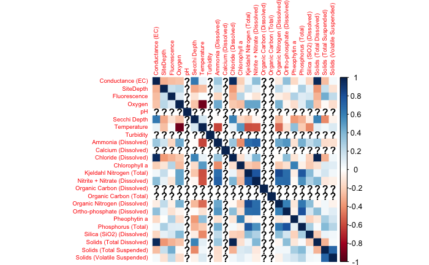

```r
#checking for correlations between factors
mycorr <- cor(wq.dat.05_12.mean)
corrplot(mycorr, method = "color", tl.cex = 0.6)
```

Checking for Normality of Factors (requirement for linear regression) Ones that look non-linear are * Tubidity * Silica (Dissolved) * Chlorophyll a! (So does that mean we can’t predict using a linear model) - I will continue as planned

```
$`Conductance (EC)`

$SiteDepth

$Fluorescence

$Oxygen

$pH

$`Secchi Depth`

$Temperature

$Turbidity

$`Ammonia (Dissolved)`

$`Calcium (Dissolved)`

$`Chloride (Dissolved)`

$`Chlorophyll a`

$`Kjeldahl Nitrogen (Total)`

$`Nitrite + Nitrate (Dissolved)`

$`Organic Carbon (Dissolved)`

$`Organic Carbon (Total)`

$`Organic Nitrogen (Dissolved)`

$`Ortho-phosphate (Dissolved)`

$`Pheophytin a`

$`Phosphorus (Total)`

$`Silica (SiO2) (Dissolved)`

$`Solids (Total Dissolved)`

$`Solids (Total Suspended)`

$`Solids (Volatile Suspended)`
```

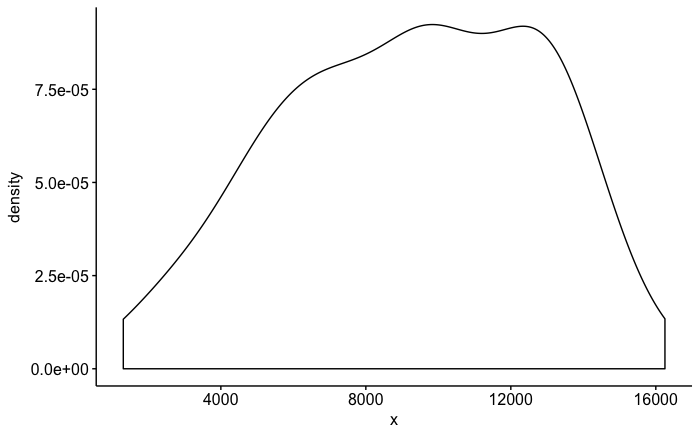

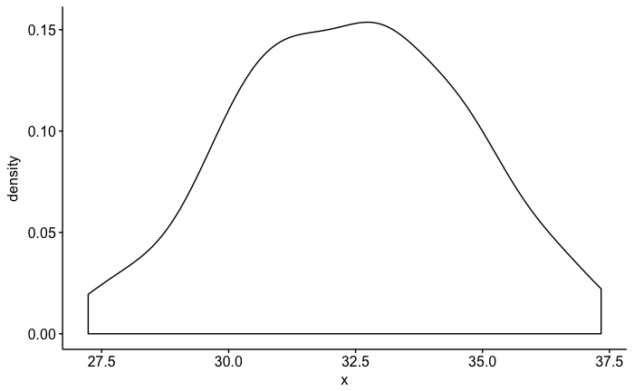

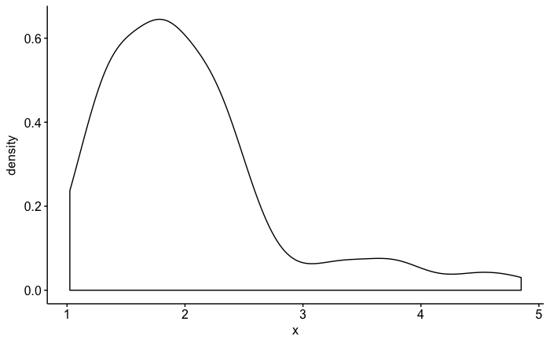

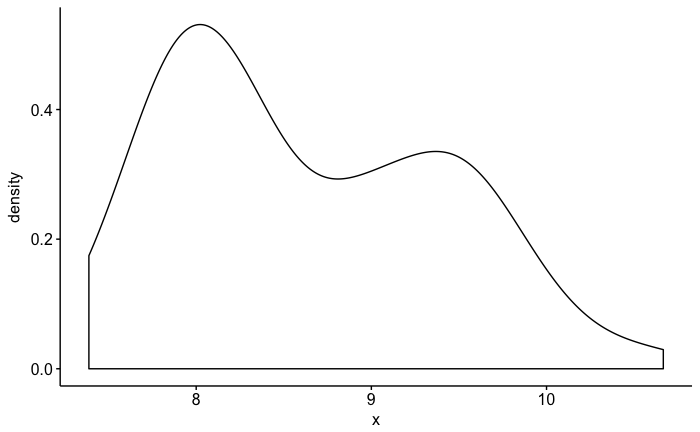

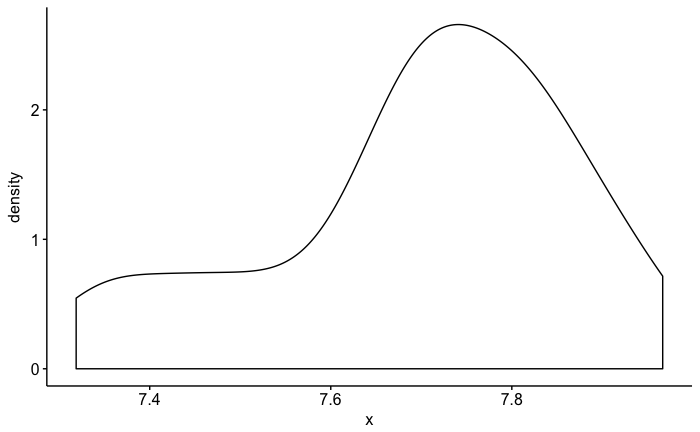

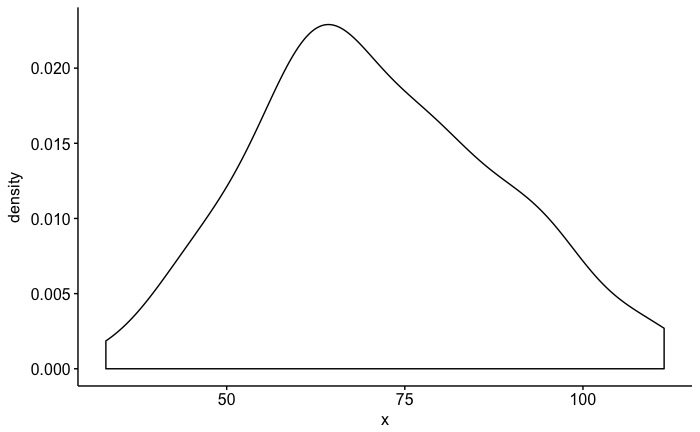

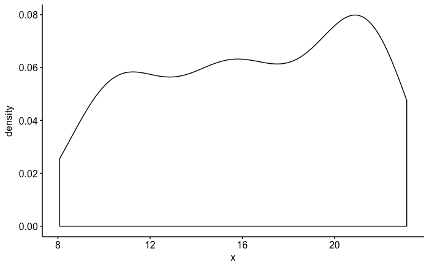

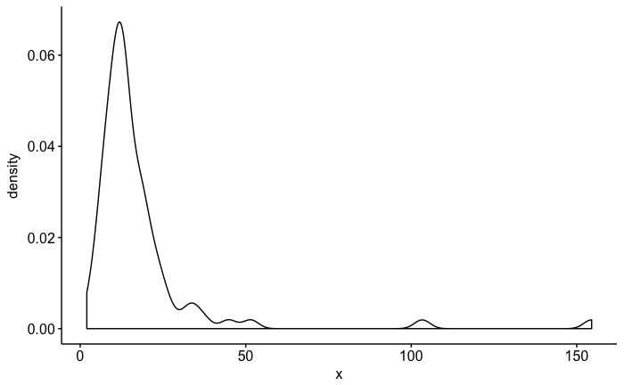

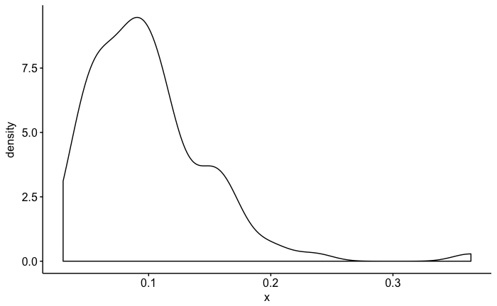

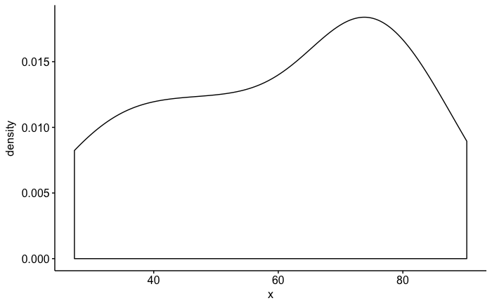

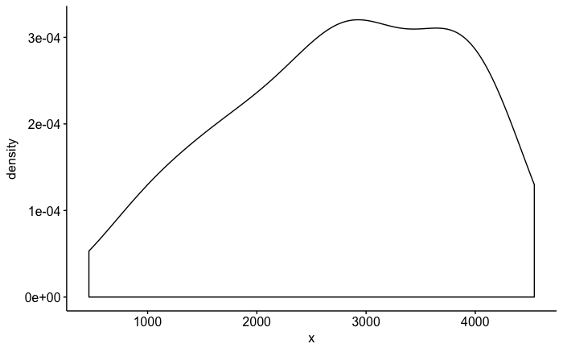

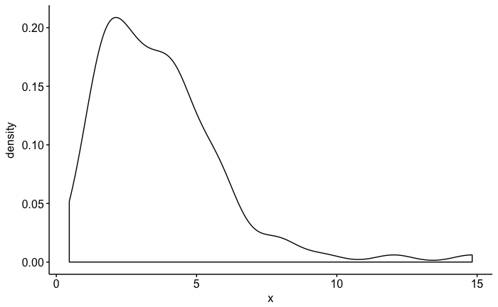

[12 more figures not shown]

```r
#checking for normalilty of factors
density.wq <-  lapply(wq.dat.05_12.mean, ggdensity)
density.wq
```

```
$`Conductance (EC)`

$SiteDepth

$Fluorescence

$Oxygen

$pH

$`Secchi Depth`

$Temperature

$Turbidity

$`Ammonia (Dissolved)`

$`Calcium (Dissolved)`

$`Chloride (Dissolved)`

$`Chlorophyll a`

$`Kjeldahl Nitrogen (Total)`

$`Nitrite + Nitrate (Dissolved)`

$`Organic Carbon (Dissolved)`

$`Organic Carbon (Total)`

$`Organic Nitrogen (Dissolved)`

$`Ortho-phosphate (Dissolved)`

$`Pheophytin a`

$`Phosphorus (Total)`

$`Silica (SiO2) (Dissolved)`

$`Solids (Total Dissolved)`

$`Solids (Total Suspended)`

$`Solids (Volatile Suspended)`
```

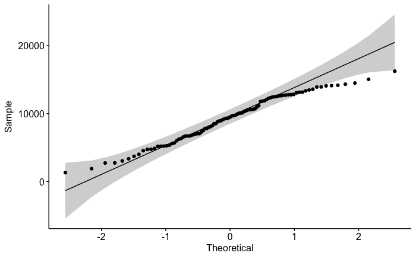

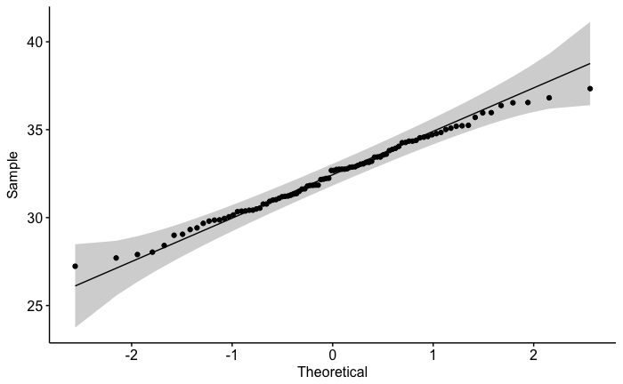

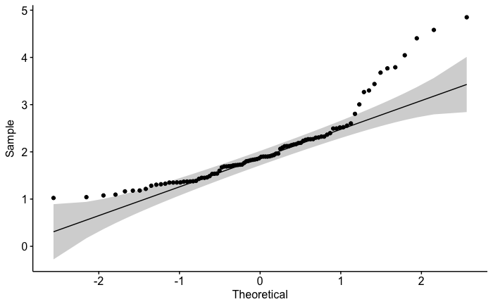

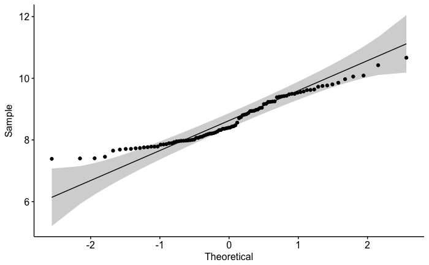

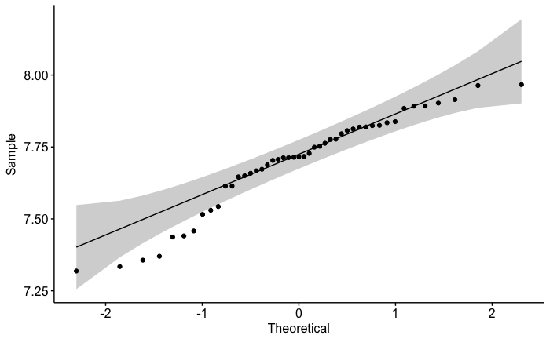

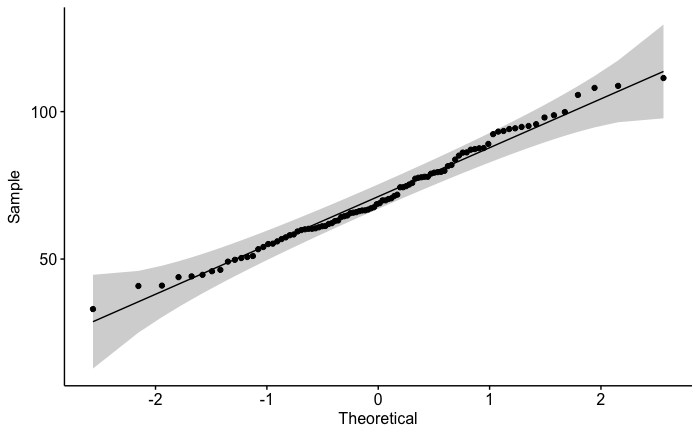

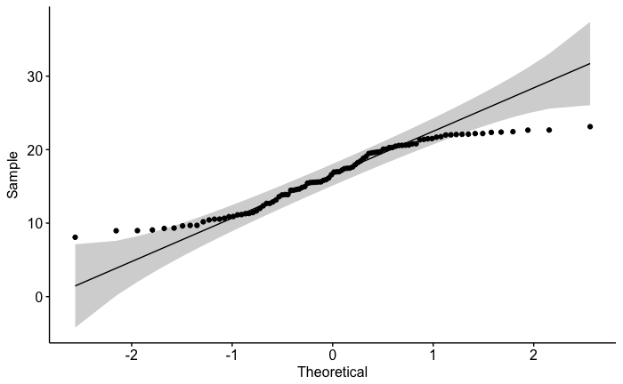

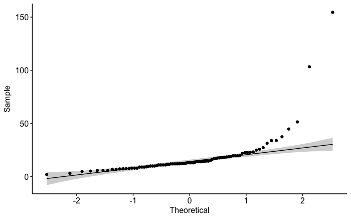

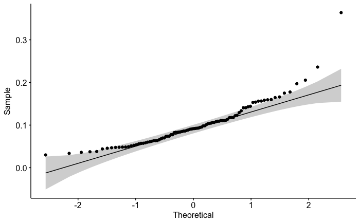

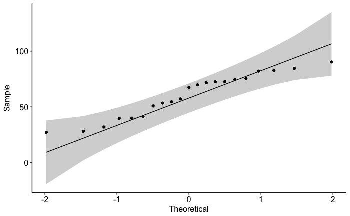

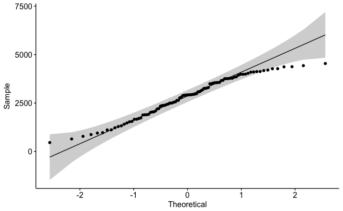

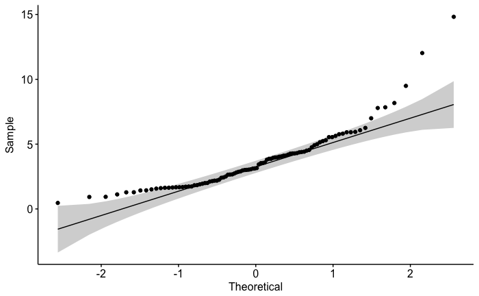

[12 more figures not shown]

```r
qq.wq <- lapply(wq.dat.05_12.mean, ggqqplot)
qq.wq
```

```r
wq.dat.05_12.mean <- wq.dat.05_12.mean[-c(8,21)] #getting rid of turbidity and silica
head(wq.dat.05_12.mean)
```

| Conductance (EC) | SiteDepth | Fluorescence | Oxygen | pH | Secchi Depth | Temperature | Ammonia (Dissolved) | Calcium (Dissolved) | Chloride (Dissolved) | Chlorophyll a | Kjeldahl Nitrogen (Total) | Nitrite + Nitrate (Dissolved) | Organic Carbon (Dissolved) | Organic Carbon (Total) | Organic Nitrogen (Dissolved) | Ortho-phosphate (Dissolved) | Pheophytin a | Phosphorus (Total) | Solids (Total Dissolved) | Solids (Total Suspended) | Solids (Volatile Suspended) |
| --- | --- | --- | --- | --- | --- | --- | --- | --- | --- | --- | --- | --- | --- | --- | --- | --- | --- | --- | --- | --- | --- |
| 7018.000 | 36.53182 | 1.766364 | 9.432800 | NA | 44.65217 | 8.961600 | 0.15642857 | NA | 2093.9286 | 0.9232143 | 0.8357143 | 0.6800000 | NA | NA | 0.5571429 | 0.11428571 | 1.1332143 | 0.22357143 | 3730.214 | 41.28571 | 6.461538 |
| 3712.455 | 34.84348 | 1.690909 | 9.572500 | NA | 44.13043 | 10.429167 | 0.06769231 | NA | 875.6923 | 1.6750000 | 0.4181818 | 0.5123077 | NA | NA | 0.2900000 | 0.06153846 | 0.6223333 | 0.10615385 | 1642.115 | 20.92308 | 2.727273 |
| 10620.379 | 31.27391 | 2.155357 | 10.666667 | 7.650 | 53.34783 | 8.076667 | 0.15615385 | NA | 3755.3077 | 3.0137037 | 0.5153846 | 0.7461538 | NA | NA | 0.4230769 | 0.05230769 | 1.7207407 | 0.08923077 | 6396.846 | 17.15385 | 2.461538 |
| 8906.565 | 35.22174 | 2.163636 | 9.495833 | NA | 43.86957 | 9.066667 | 0.19692308 | NA | 2768.6923 | 1.6866667 | 0.9769231 | 1.0538462 | NA | NA | 0.8000000 | 0.08846154 | 1.7280952 | 0.18230769 | 5073.654 | 28.69231 | 5.538462 |
| 12234.619 | 28.41429 | 1.350000 | 9.765909 | NA | 81.52381 | 9.327273 | 0.20545455 | NA | 4202.1538 | 2.1850000 | 0.7153846 | 0.9061538 | NA | NA | 0.3923077 | 0.07769231 | 0.6654545 | 0.10615385 | 7509.000 | 12.15385 | 4.200000 |
| 16252.000 | 31.84783 | 1.863636 | 9.620833 | 7.543 | 79.91304 | 9.695833 | 0.15933333 | NA | 3778.7333 | 1.6714286 | 0.5400000 | 0.7713333 | NA | NA | 0.2600000 | 0.06066667 | 1.3990476 | 0.10666667 | 6899.867 | 21.93333 | 5.333333 |

Check for heteroscedastic * of the variables modelled, none of them look homoscedastic

[figure not shown]

```r
#this is not helpful, but I'm leaving it
pairs(~`Conductance (EC)` + SiteDepth + Fluorescence + Oxygen + pH + `Secchi Depth` + Temperature + `Ammonia (Dissolved)` + `Calcium (Dissolved)` + `Chloride (Dissolved)` + `Kjeldahl Nitrogen (Total)` + `Nitrite + Nitrate (Dissolved)` + `Organic Carbon (Dissolved)` + `Organic Carbon (Total)` + `Organic Nitrogen (Dissolved)` + `Ortho-phosphate (Dissolved)` + `Pheophytin a` + `Phosphorus (Total)` + `Solids (Total Dissolved)` + `Solids (Total Suspended)` + `Solids (Volatile Suspended)`, data = wq.dat.05_12.mean)
```

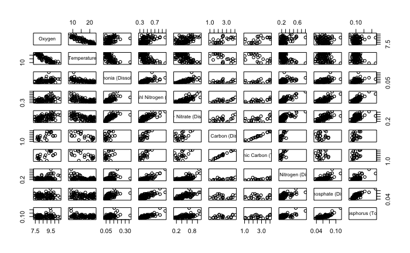

```r
#below are all the variables I modelled
pairs(~ Oxygen + Temperature + `Ammonia (Dissolved)` +`Kjeldahl Nitrogen (Total)` + `Nitrite + Nitrate (Dissolved)` + `Organic Carbon (Dissolved)` + `Organic Carbon (Total)` + `Organic Nitrogen (Dissolved)` + `Ortho-phosphate (Dissolved)` + `Phosphorus (Total)`, data = wq.dat.05_12.mean)
```

### (3) A summary and comparison of 4 models developed

Null Model

```r
lm.null <- lm(`Chlorophyll a` ~ 1, data = wq.dat.05_12.mean)
```

Nitrogen Model * Using StepAIC, it appears that following are the best nitrogen indicators - Kjeldahl Nitrogen (Total)  
- Organic Nitrogen (Dissolved) - Ammonia (Dissolved)

```r
lm.nitrogen <- step(lm( `Chlorophyll a` ~ `Kjeldahl Nitrogen (Total)` + `Nitrite + Nitrate (Dissolved)` + `Organic Nitrogen (Dissolved)` + `Ammonia (Dissolved)`, data = wq.dat.05_12.mean))
```

```
Start:  AIC=146.7
`Chlorophyll a` ~ `Kjeldahl Nitrogen (Total)` + `Nitrite + Nitrate (Dissolved)` +
    `Organic Nitrogen (Dissolved)` + `Ammonia (Dissolved)`

                                  Df Sum of Sq    RSS    AIC
- `Nitrite + Nitrate (Dissolved)`  1     1.464 400.20 145.05
<none>                                         398.74 146.70
- `Kjeldahl Nitrogen (Total)`      1    13.660 412.40 147.93
- `Organic Nitrogen (Dissolved)`   1    15.848 414.59 148.44
- `Ammonia (Dissolved)`            1    68.341 467.08 159.89

Step:  AIC=145.05
`Chlorophyll a` ~ `Kjeldahl Nitrogen (Total)` + `Organic Nitrogen (Dissolved)` +
    `Ammonia (Dissolved)`

                                 Df Sum of Sq    RSS    AIC
<none>                                        400.20 145.05
- `Organic Nitrogen (Dissolved)`  1    14.493 414.69 146.47
- `Kjeldahl Nitrogen (Total)`     1    16.740 416.94 146.99
- `Ammonia (Dissolved)`           1    77.049 477.25 159.96
```

```r
summary(lm.nitrogen)
```

```
Call:
lm(formula = `Chlorophyll a` ~ `Kjeldahl Nitrogen (Total)` +
    `Organic Nitrogen (Dissolved)` + `Ammonia (Dissolved)`, data = wq.dat.05_12.mean)

Residuals:
    Min      1Q  Median      3Q     Max
-3.0583 -1.3318 -0.3460  0.5809 10.0569

Coefficients:
                               Estimate Std. Error t value Pr(>|t|)
(Intercept)                      4.6075     0.8431   5.465 3.93e-07 ***
`Kjeldahl Nitrogen (Total)`      7.1937     3.6671   1.962   0.0528 .
`Organic Nitrogen (Dissolved)`  -6.6010     3.6164  -1.825   0.0712 .
`Ammonia (Dissolved)`          -24.7933     5.8911  -4.209 5.97e-05 ***
---
Signif. codes:  0 ‘***’ 0.001 ‘**’ 0.01 ‘*’ 0.05 ‘.’ 0.1 ‘ ’ 1

Residual standard error: 2.086 on 92 degrees of freedom
Multiple R-squared:  0.2067,    Adjusted R-squared:  0.1809
F-statistic: 7.993 on 3 and 92 DF,  p-value: 8.606e-05
```

Temperature or Oxygen (?) * Temperature seems like a stronger indicator than Oxygen

```r
lm.TO <- step(lm(`Chlorophyll a` ~Oxygen + Temperature, data = wq.dat.05_12.mean))
```

```
Start:  AIC=102.03
`Chlorophyll a` ~ Oxygen + Temperature

              Df Sum of Sq    RSS    AIC
<none>                     261.04 102.03
- Oxygen       1    112.54 373.58 134.44
- Temperature  1    206.93 467.96 156.07
```

All EPA indicators Model (Nutrients and Oxygen) * Final results show the following are best - Kjeldahl Nitrogen (Total) - Oxygen  
- Temperature

```r
lm.EPA <- step(lm( `Chlorophyll a` ~ `Kjeldahl Nitrogen (Total)` + `Nitrite + Nitrate (Dissolved)` + `Organic Nitrogen (Dissolved)` + `Ammonia (Dissolved)` + Oxygen + Temperature + `Phosphorus (Total)` + `Ortho-phosphate (Dissolved)` , data = wq.dat.05_12.mean))
```

```
Start:  AIC=104.29
`Chlorophyll a` ~ `Kjeldahl Nitrogen (Total)` + `Nitrite + Nitrate (Dissolved)` +
    `Organic Nitrogen (Dissolved)` + `Ammonia (Dissolved)` +
    Oxygen + Temperature + `Phosphorus (Total)` + `Ortho-phosphate (Dissolved)`

                                  Df Sum of Sq    RSS    AIC
- `Ortho-phosphate (Dissolved)`    1     0.009 235.85 102.29
- `Phosphorus (Total)`             1     0.078 235.92 102.32
- `Nitrite + Nitrate (Dissolved)`  1     0.193 236.04 102.36
- `Ammonia (Dissolved)`            1     1.964 237.81 103.08
- `Organic Nitrogen (Dissolved)`   1     4.329 240.17 104.03
<none>                                         235.84 104.29
- `Kjeldahl Nitrogen (Total)`      1    11.583 247.43 106.89
- Oxygen                           1    87.864 323.71 132.69
- Temperature                      1   155.976 391.82 151.02

Step:  AIC=102.29
`Chlorophyll a` ~ `Kjeldahl Nitrogen (Total)` + `Nitrite + Nitrate (Dissolved)` +
    `Organic Nitrogen (Dissolved)` + `Ammonia (Dissolved)` +
    Oxygen + Temperature + `Phosphorus (Total)`

                                  Df Sum of Sq    RSS    AIC
- `Phosphorus (Total)`             1     0.079 235.93 100.32
- `Nitrite + Nitrate (Dissolved)`  1     0.345 236.20 100.43
- `Ammonia (Dissolved)`            1     1.976 237.83 101.09
- `Organic Nitrogen (Dissolved)`   1     4.405 240.26 102.07
<none>                                         235.85 102.29
- `Kjeldahl Nitrogen (Total)`      1    11.711 247.56 104.94
- Oxygen                           1   101.517 337.37 134.66
- Temperature                      1   156.390 392.24 149.12

Step:  AIC=100.32
`Chlorophyll a` ~ `Kjeldahl Nitrogen (Total)` + `Nitrite + Nitrate (Dissolved)` +
    `Organic Nitrogen (Dissolved)` + `Ammonia (Dissolved)` +
    Oxygen + Temperature

                                  Df Sum of Sq    RSS     AIC
- `Nitrite + Nitrate (Dissolved)`  1     0.344 236.27  98.462
- `Ammonia (Dissolved)`            1     1.939 237.87  99.108
- `Organic Nitrogen (Dissolved)`   1     4.384 240.31 100.090
```

[output cut: 21 more lines]

```
                                 Df Sum of Sq    RSS     AIC
- `Organic Nitrogen (Dissolved)`  1     2.999 240.87  96.311
<none>                                        237.87  97.108
- `Kjeldahl Nitrogen (Total)`     1    17.975 255.85 102.102
- Oxygen                          1   129.152 367.02 136.743
- Temperature                     1   222.072 459.94 158.408

Step:  AIC=96.31
`Chlorophyll a` ~ `Kjeldahl Nitrogen (Total)` + Oxygen + Temperature

                              Df Sum of Sq    RSS     AIC
<none>                                     240.87  96.311
- `Kjeldahl Nitrogen (Total)`  1    20.169 261.04 102.031
- Oxygen                       1   127.862 368.73 135.189
- Temperature                  1   221.457 462.33 156.905
```

```r
summary(lm.EPA)
```

```
Call:
lm(formula = `Chlorophyll a` ~ `Kjeldahl Nitrogen (Total)` +
    Oxygen + Temperature, data = wq.dat.05_12.mean)

Residuals:
    Min      1Q  Median      3Q     Max
-2.6593 -0.9238 -0.3384  0.4676  9.4516

Coefficients:
                            Estimate Std. Error t value Pr(>|t|)
(Intercept)                 -45.0849     6.2763  -7.183 1.73e-10 ***
`Kjeldahl Nitrogen (Total)`   4.5124     1.6258   2.775  0.00668 **
Oxygen                        3.6453     0.5216   6.988 4.30e-10 ***
Temperature                   0.9291     0.1010   9.197 1.12e-14 ***
---
Signif. codes:  0 ‘***’ 0.001 ‘**’ 0.01 ‘*’ 0.05 ‘.’ 0.1 ‘ ’ 1

Residual standard error: 1.618 on 92 degrees of freedom
Multiple R-squared:  0.5226,    Adjusted R-squared:  0.507
F-statistic: 33.57 on 3 and 92 DF,  p-value: 9.565e-15
```

EPA without Oxygen

```r
lm.EPA.noO <- step(lm(`Chlorophyll a` ~ `Kjeldahl Nitrogen (Total)` + `Nitrite + Nitrate (Dissolved)` + `Organic Nitrogen (Dissolved)` + `Ammonia (Dissolved)` + Temperature + `Phosphorus (Total)` + `Ortho-phosphate (Dissolved)`, data = wq.dat.05_12.mean))
```

```
Start:  AIC=132.69
`Chlorophyll a` ~ `Kjeldahl Nitrogen (Total)` + `Nitrite + Nitrate (Dissolved)` +
    `Organic Nitrogen (Dissolved)` + `Ammonia (Dissolved)` +
    Temperature + `Phosphorus (Total)` + `Ortho-phosphate (Dissolved)`

                                  Df Sum of Sq    RSS    AIC
- `Phosphorus (Total)`             1     1.138 324.84 131.02
- `Organic Nitrogen (Dissolved)`   1     4.540 328.25 132.02
<none>                                         323.71 132.69
- `Nitrite + Nitrate (Dissolved)`  1    10.524 334.23 133.76
- `Kjeldahl Nitrogen (Total)`      1    12.752 336.46 134.40
- `Ortho-phosphate (Dissolved)`    1    13.662 337.37 134.66
- `Ammonia (Dissolved)`            1    15.224 338.93 135.10
- Temperature                      1    71.734 395.44 149.90

Step:  AIC=131.02
`Chlorophyll a` ~ `Kjeldahl Nitrogen (Total)` + `Nitrite + Nitrate (Dissolved)` +
    `Organic Nitrogen (Dissolved)` + `Ammonia (Dissolved)` +
    Temperature + `Ortho-phosphate (Dissolved)`

                                  Df Sum of Sq    RSS    AIC
- `Organic Nitrogen (Dissolved)`   1     5.227 330.07 130.56
<none>                                         324.84 131.02
- `Nitrite + Nitrate (Dissolved)`  1     9.390 334.23 131.76
- `Ortho-phosphate (Dissolved)`    1    14.760 339.61 133.29
- `Ammonia (Dissolved)`            1    17.458 342.30 134.05
- `Kjeldahl Nitrogen (Total)`      1    25.433 350.28 136.26
- Temperature                      1    71.301 396.15 148.07

Step:  AIC=130.56
`Chlorophyll a` ~ `Kjeldahl Nitrogen (Total)` + `Nitrite + Nitrate (Dissolved)` +
    `Ammonia (Dissolved)` + Temperature + `Ortho-phosphate (Dissolved)`

                                  Df Sum of Sq    RSS    AIC
<none>                                         330.07 130.56
- `Nitrite + Nitrate (Dissolved)`  1     7.797 337.87 130.80
- `Ammonia (Dissolved)`            1    12.961 343.03 132.25
- `Ortho-phosphate (Dissolved)`    1    17.984 348.06 133.65
- `Kjeldahl Nitrogen (Total)`      1    21.107 351.18 134.51
- Temperature                      1    82.429 412.50 149.96
```

```r
lm.EPA.nostep <- lm( `Chlorophyll a` ~ `Kjeldahl Nitrogen (Total)` + `Nitrite + Nitrate (Dissolved)` + `Organic Nitrogen (Dissolved)` + `Ammonia (Dissolved)` + Oxygen + Temperature + `Phosphorus (Total)` + `Ortho-phosphate (Dissolved)` , data = wq.dat.05_12.mean)
summary(lm.EPA.nostep)
```

```
Call:
lm(formula = `Chlorophyll a` ~ `Kjeldahl Nitrogen (Total)` +
    `Nitrite + Nitrate (Dissolved)` + `Organic Nitrogen (Dissolved)` +
    `Ammonia (Dissolved)` + Oxygen + Temperature + `Phosphorus (Total)` +
    `Ortho-phosphate (Dissolved)`, data = wq.dat.05_12.mean)

Residuals:
    Min      1Q  Median      3Q     Max
-2.6919 -0.9206 -0.2722  0.4712  9.2080

Coefficients:
                                Estimate Std. Error t value Pr(>|t|)
(Intercept)                     -43.2225     7.3947  -5.845 8.64e-08 ***
`Kjeldahl Nitrogen (Total)`       7.7885     3.7678   2.067   0.0417 *
`Nitrite + Nitrate (Dissolved)`   0.4728     1.7716   0.267   0.7902
`Organic Nitrogen (Dissolved)`   -3.8109     3.0157  -1.264   0.2097
`Ammonia (Dissolved)`            -5.1942     6.1022  -0.851   0.3970
Oxygen                            3.5031     0.6153   5.693 1.66e-07 ***
Temperature                       0.8883     0.1171   7.585 3.42e-11 ***
`Phosphorus (Total)`             -2.8509    16.8029  -0.170   0.8657
`Ortho-phosphate (Dissolved)`     1.7035    30.4050   0.056   0.9554
---
Signif. codes:  0 ‘***’ 0.001 ‘**’ 0.01 ‘*’ 0.05 ‘.’ 0.1 ‘ ’ 1

Residual standard error: 1.646 on 87 degrees of freedom
Multiple R-squared:  0.5325,    Adjusted R-squared:  0.4895
F-statistic: 12.39 on 8 and 87 DF,  p-value: 1.084e-11
```

Compare and contrast [Copied directly from notes] * Best model was the EPA model that included Temp, Oxygen, and Kjeldal Nit. - Had the highest adj-R^2 and the lowest AIC

```r
lms <- list(null=lm.null, Temp.and.O2 = lm.TO , EPA = lm.EPA, EPA.noO = lm.EPA.noO, EPA.nostep = lm.EPA.nostep)
lms.stats <- mapply(glance, lms)
colnames(lms.stats) <- names(lms)
lms.stats
```

```
              null      Temp.and.O2  EPA          EPA.noO      EPA.nostep
r.squared     0         0.4825871    0.522564     0.3457527    0.5325281
adj.r.squared 0         0.4714599    0.5069954    0.3094056    0.4895422
sigma         2.304473  1.675369     1.618069     1.915063     1.646461
statistic     NA        43.37019     33.56533     9.512531     12.38843
p.value       NA        4.936665e-14 9.564854e-15 2.612484e-07 1.083896e-11
df            1         3            4            6            9
logLik        -215.8612 -184.2334    -180.3736    -195.4963    -179.3613
AIC           435.7225  376.4668     370.7473     404.9926     378.7226
BIC           440.8512  386.7241     383.569      422.943      404.366
deviance      504.5064  261.0381     240.8695     330.072      235.8426
df.residual   95        93           92           90           87
```

```r
aic <- as.data.frame(unlist(lms.stats["AIC",]))
colnames(aic) <- "AIC"
aic
```

|  | AIC |
| --- | --- |
| null | 435.7225 |
| Temp.and.O2 | 376.4668 |
| EPA | 370.7473 |
| EPA.noO | 404.9926 |
| EPA.nostep | 378.7226 |

```r
bic <- as.data.frame(unlist(lms.stats["BIC",]))
colnames(bic) <- "BIC"
bic
```

|  | BIC |
| --- | --- |
| null | 440.8512 |
| Temp.and.O2 | 386.7241 |
| EPA | 383.5690 |
| EPA.noO | 422.9430 |
| EPA.nostep | 404.3660 |

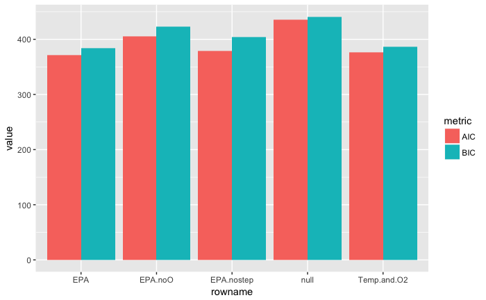

```r
aic.bic <- cbind(aic,bic)
a.b <- aic.bic %>%
  rownames_to_column() %>%
  gather(metric, value, -rowname) %>%
  ggplot(aes(rowname, value, fill = metric)) +
  geom_bar(position = "dodge", stat = "identity")
a.b
```

ANOVA of models

```r
a <- anova(lm.TO, lm.EPA, lm.EPA.noO, lm.EPA.nostep)
a
```

```
Analysis of Variance Table

Model 1: `Chlorophyll a` ~ Oxygen + Temperature
Model 2: `Chlorophyll a` ~ `Kjeldahl Nitrogen (Total)` + Oxygen + Temperature
Model 3: `Chlorophyll a` ~ `Kjeldahl Nitrogen (Total)` + `Nitrite + Nitrate (Dissolved)` +
    `Ammonia (Dissolved)` + Temperature + `Ortho-phosphate (Dissolved)`
Model 4: `Chlorophyll a` ~ `Kjeldahl Nitrogen (Total)` + `Nitrite + Nitrate (Dissolved)` +
    `Organic Nitrogen (Dissolved)` + `Ammonia (Dissolved)` +
    Oxygen + Temperature + `Phosphorus (Total)` + `Ortho-phosphate (Dissolved)`
  Res.Df    RSS Df Sum of Sq      F    Pr(>F)
1     93 261.04
2     92 240.87  1    20.169  7.440  0.007716 **
3     90 330.07  2   -89.202
4     87 235.84  3    94.229 11.587 1.839e-06 ***
---
Signif. codes:  0 ‘***’ 0.001 ‘**’ 0.01 ‘*’ 0.05 ‘.’ 0.1 ‘ ’ 1
```

```r
stem(residuals(lm.EPA))
```

```
  The decimal point is at the |

  -2 | 71
  -0 | 76644444332221009999999998877777666655555544443333322222111
   0 | 1122223333555667792233344478
   2 | 00165
   4 |
   6 | 4
   8 | 5
```

```r
stem(residuals(lm.EPA.noO))
```

```
  The decimal point is at the |

  -2 | 4320
  -0 | 9998888766655554443332221100999998887666655433222211
   0 | 00222334444566789990000123558
   2 | 04555716
   4 | 7
   6 | 3
   8 | 8
```

```r
stem(residuals(lm.EPA.nostep))
```

```
  The decimal point is at the |

  -2 | 75
  -0 | 8666544333222221100099988887777766655554443333322221111110000
   0 | 001233345556780111223345889
   2 | 1362
   4 |
   6 | 1
   8 | 2
```

```r
stem(residuals(lm.TO))
```

```
  The decimal point is at the |

  -2 | 8
  -0 | 777666555433333321111110099999888876655544444322100
   0 | 00000111112223444455566677889990046779
   2 | 133
   4 | 1
   6 | 8
   8 | 8
```

2. Parallel Regression- Parallel regression specifies an additive model, where there is one regression line (for the continuous predictor) which is displaced vertically according to the mean value of the discrete predictor. It hypothesizes that the only effect of the discrete predictor is to adjust the mean, but that the relation between the continuous predictor and the response variable is then the same for all classes of the discrete predictor.

Using your mean monthly water quality dataset for CA WY 2005-2012, create a new discrete value called “season”, and assign a label to your data for “wet season” and “dry season” (you will have decide what constitutes wet and dry). Model the mean monthly Chl-a concentration as a function of season and the water quality variable you idenitifed as MOST important in explaining the variance of Chl-a from question 1.

In the parallel regression model (season and your most important variable as predictors), what are the differences in the means between seasons? What is the slope of the linear regression after accounting for season? How does this compare with the slope of the linear regression not considering season? Are the residuals normally distributed? Plot Chl-a vs your most important variable, with the observations colored by season. Add the paralell regression lines from the combined model in the appropraite colors, and add the univariate regression line.

### Data Wrangling (adding season)

Do I get to define what a season is too?

Looking at this website (https://www.timeanddate.com/weather/@5389649/climate) * Averages are for Buchanan Field, which is 13 miles from Sacramento-San Joaquin Delta. * Based on weather reports collected during 1985–2015. - Wet months (>0.25 in rain) = November, December, January, Febrauary, March, April (11:12, 1:4) - Dry months (<0.25 in rain) = May, June, July, August, September, October

```r
#adding season column from data wranging above
wq.dat.05_12.mean <-  add_column(wq.dat.05_12.mean, Season = as.factor(season))
head(wq.dat.05_12.mean)
```

| Conductance (EC) | SiteDepth | Fluorescence | Oxygen | pH | Secchi Depth | Temperature | Ammonia (Dissolved) | Calcium (Dissolved) | Chloride (Dissolved) | Chlorophyll a | Kjeldahl Nitrogen (Total) | Nitrite + Nitrate (Dissolved) | Organic Carbon (Dissolved) | Organic Carbon (Total) | Organic Nitrogen (Dissolved) | Ortho-phosphate (Dissolved) | Pheophytin a | Phosphorus (Total) | Solids (Total Dissolved) | Solids (Total Suspended) | Solids (Volatile Suspended) | Season |
| --- | --- | --- | --- | --- | --- | --- | --- | --- | --- | --- | --- | --- | --- | --- | --- | --- | --- | --- | --- | --- | --- | --- |
| 7018.000 | 36.53182 | 1.766364 | 9.432800 | NA | 44.65217 | 8.961600 | 0.15642857 | NA | 2093.9286 | 0.9232143 | 0.8357143 | 0.6800000 | NA | NA | 0.5571429 | 0.11428571 | 1.1332143 | 0.22357143 | 3730.214 | 41.28571 | 6.461538 | wet |
| 3712.455 | 34.84348 | 1.690909 | 9.572500 | NA | 44.13043 | 10.429167 | 0.06769231 | NA | 875.6923 | 1.6750000 | 0.4181818 | 0.5123077 | NA | NA | 0.2900000 | 0.06153846 | 0.6223333 | 0.10615385 | 1642.115 | 20.92308 | 2.727273 | wet |
| 10620.379 | 31.27391 | 2.155357 | 10.666667 | 7.650 | 53.34783 | 8.076667 | 0.15615385 | NA | 3755.3077 | 3.0137037 | 0.5153846 | 0.7461538 | NA | NA | 0.4230769 | 0.05230769 | 1.7207407 | 0.08923077 | 6396.846 | 17.15385 | 2.461538 | wet |
| 8906.565 | 35.22174 | 2.163636 | 9.495833 | NA | 43.86957 | 9.066667 | 0.19692308 | NA | 2768.6923 | 1.6866667 | 0.9769231 | 1.0538462 | NA | NA | 0.8000000 | 0.08846154 | 1.7280952 | 0.18230769 | 5073.654 | 28.69231 | 5.538462 | wet |
| 12234.619 | 28.41429 | 1.350000 | 9.765909 | NA | 81.52381 | 9.327273 | 0.20545455 | NA | 4202.1538 | 2.1850000 | 0.7153846 | 0.9061538 | NA | NA | 0.3923077 | 0.07769231 | 0.6654545 | 0.10615385 | 7509.000 | 12.15385 | 4.200000 | wet |
| 16252.000 | 31.84783 | 1.863636 | 9.620833 | 7.543 | 79.91304 | 9.695833 | 0.15933333 | NA | 3778.7333 | 1.6714286 | 0.5400000 | 0.7713333 | NA | NA | 0.2600000 | 0.06066667 | 1.3990476 | 0.10666667 | 6899.867 | 21.93333 | 5.333333 | wet |

### Regression Analysis

Linear Regression

```r
summary(lm.season)
```

```
Call:
lm(formula = `Chlorophyll a` ~ season, data = wq.dat.05_12.mean)

Residuals:
    Min      1Q  Median      3Q     Max
-2.7434 -1.3911 -0.5860  0.9637 10.2433

Coefficients:
            Estimate Std. Error t value Pr(>|t|)
(Intercept)   4.5820     0.3088  14.838  < 2e-16 ***
seasonwet    -1.7591     0.4367  -4.028 0.000114 ***
---
Signif. codes:  0 ‘***’ 0.001 ‘**’ 0.01 ‘*’ 0.05 ‘.’ 0.1 ‘ ’ 1

Residual standard error: 2.139 on 94 degrees of freedom
Multiple R-squared:  0.1472,    Adjusted R-squared:  0.1381
F-statistic: 16.23 on 1 and 94 DF,  p-value: 0.0001139
```

```
There were 50 or more warnings (use warnings() to see the first 50)
```

```r
summary(lm.temp)
```

```
Call:
lm(formula = `Chlorophyll a` ~ Temperature, data = wq.dat.05_12.mean)

Residuals:
    Min      1Q  Median      3Q     Max
-2.5746 -1.3987 -0.3991  0.6842  9.9623

Coefficients:
            Estimate Std. Error t value Pr(>|t|)
(Intercept) -0.62954    0.78167  -0.805    0.423
Temperature  0.26406    0.04601   5.740 1.15e-07 ***
---
Signif. codes:  0 ‘***’ 0.001 ‘**’ 0.01 ‘*’ 0.05 ‘.’ 0.1 ‘ ’ 1

Residual standard error: 1.994 on 94 degrees of freedom
Multiple R-squared:  0.2595,    Adjusted R-squared:  0.2516
F-statistic: 32.94 on 1 and 94 DF,  p-value: 1.154e-07
```

```r
summary(lm.season.temp)
```

```
Call:
lm(formula = `Chlorophyll a` ~ season + Temperature, data = wq.dat.05_12.mean)

Residuals:
    Min      1Q  Median      3Q     Max
-2.5509 -1.2827 -0.3877  0.6177 10.0420

Coefficients:
            Estimate Std. Error t value Pr(>|t|)
(Intercept) -3.23911    1.94187  -1.668   0.0987 .
seasonwet    1.22848    0.83779   1.466   0.1459
Temperature  0.38569    0.09472   4.072 9.79e-05 ***
---
Signif. codes:  0 ‘***’ 0.001 ‘**’ 0.01 ‘*’ 0.05 ‘.’ 0.1 ‘ ’ 1

Residual standard error: 1.981 on 93 degrees of freedom
Multiple R-squared:  0.2763,    Adjusted R-squared:  0.2607
F-statistic: 17.75 on 2 and 93 DF,  p-value: 2.956e-07
```

```r
lms <- list(null = lm.null, season = lm.season , temp = lm.temp, season.temp = lm.season.temp)
```

```
There were 50 or more warnings (use warnings() to see the first 50)
```

```r
lms.stats <- mapply(glance, lms)
colnames(lms.stats) <- names(lms)
lms.stats
```

```
              null      season       temp        season.temp
r.squared     0         0.1472136    0.2595211   0.2762537
adj.r.squared 0         0.1381414    0.2516436   0.2606893
sigma         2.304473  2.139388     1.993544    1.981459
statistic     NA        16.22689     32.94487    17.74903
p.value       NA        0.0001139183 1.15385e-07 2.956415e-07
df            1         2            2           3
logLik        -215.8612 -208.2174    -201.4393   -200.3422
AIC           435.7225  422.4349     408.8785    408.6843
BIC           440.8512  430.1279     416.5716    418.9417
deviance      504.5064  430.2362     373.5763    365.1346
df.residual   95        94           94          93
```

```r
aic <- as.data.frame(unlist(lms.stats["AIC",]))
colnames(aic) <- "AIC"
aic
```

|  | AIC |
| --- | --- |
| null | 435.7225 |
| season | 422.4349 |
| temp | 408.8785 |
| season.temp | 408.6843 |

```r
bic <- as.data.frame(unlist(lms.stats["BIC",]))
colnames(bic) <- "BIC"
bic
```

|  | BIC |
| --- | --- |
| null | 440.8512 |
| season | 430.1279 |
| temp | 416.5716 |
| season.temp | 418.9417 |

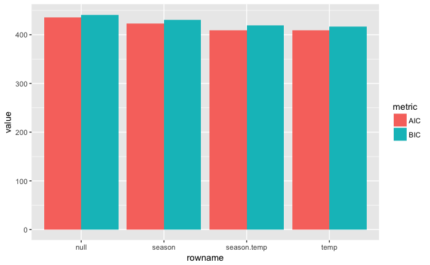

```r
aic.bic <- cbind(aic,bic)
a.b <- aic.bic %>%
  rownames_to_column() %>%
  gather(metric, value, -rowname) %>%
  ggplot(aes(rowname, value, fill = metric)) +
  geom_bar(position = "dodge", stat = "identity")
a.b
```

[output not shown]

```r
wq.dat.05_12.mean.season
```

```
There were 48 warnings (use warnings() to see them)
```

Plot Chl-a vs your most important variable, with the observations colored by season. Add the paralell regression lines from the combined model in the appropraite colors, and add the univariate regression line.

```
There were 50 or more warnings (use warnings() to see the first 50)
```

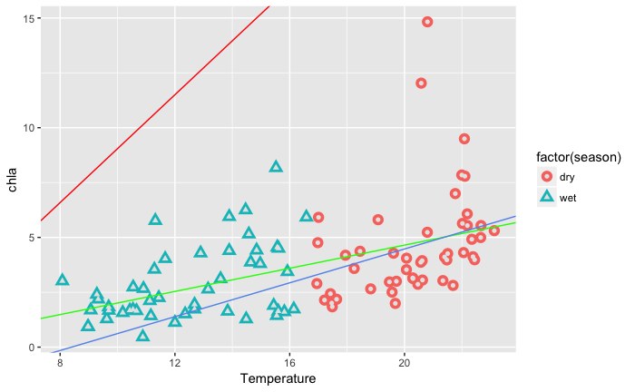

```r
p + geom_point(aes(colour = factor(season)), size = 4) +
  geom_point(colour = "grey90", size = 1.5) +
  geom_abline(intercept = -0.62954, slope = 0.26406,colour = "green", show.legend = T)+  #from lm.chla.temp
  geom_abline(intercept = 4.5820, slope = -1.7591,colour = "blue", show.legend = T) + #from lm.season
  geom_abline(intercept = -3.23911 , slope = 1.22848,colour = "red", show.legend = T) + #from lm.season.temp (season)
  geom_abline(intercept = -3.23911 , slope = 0.38569,colour = "cornflowerblue", show.legend = T) #from lm.season.temp (temp)
```

3. Push your anser to your GitHub page. Post the link in your homework response on Catcourses.